# Covid91 vaccine study Final2024

La Kayla Thompson

2024-08-01

# 1 Introduction

A new preventative vaccine (covid921) is under test in clinical trials. Given the nature of this vaccine it is suspected that the drug may exhibit different effectiveness across the variety of subpopulations tracked. Consider population subgroups by gender( guys and gals), drug use, and sexual orientation. Write a complete report that separately considers this drug for each subgroup and your recommendations as to whether people in the subgroup should take the vaccine. Structure your report in four sections each devoted to one of the four subgroups, use null and alternative hypothesis statements and correct statistical verbage when referencing p-values in conclusions.

## 1.1 Males

$H_0$: The Covid921 vaccine is not effective in MALES

$H_A$: The Covid921 vaccine is effective in MALES

### 1.1.1 Methods

Treatment is a categorical variable  
MALES is also a categorical variable  
So we use the cat~cat helper file

### 1.1.2 Descriptive Results

### 1.1.3 Graphical Results

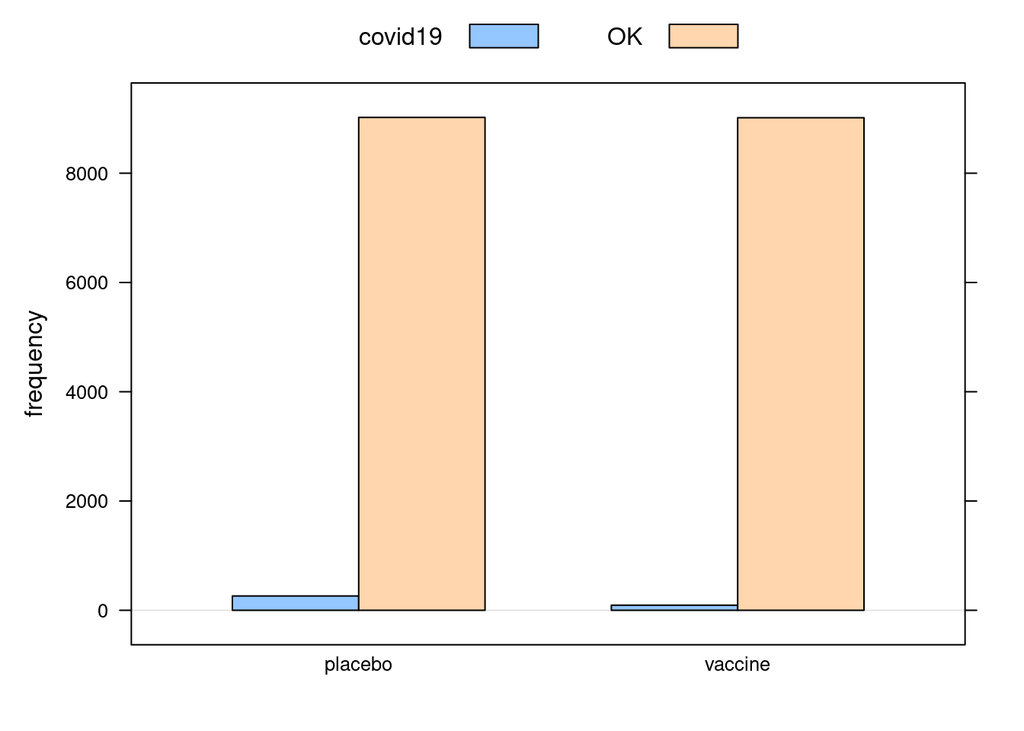

```r
males=filter(FinalData,FinalData$sex=="M")
barchartGC(~treatment + infected,data=males)
```

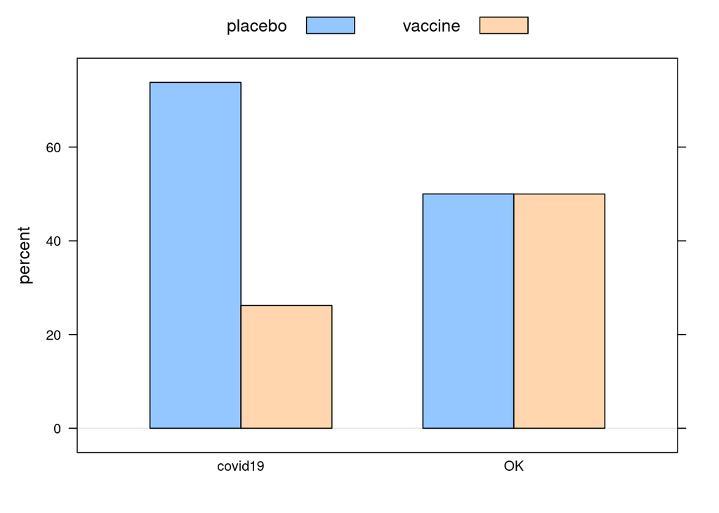

```r
barchartGC(~infected + treatment,data=males, type="percent")
```

### 1.1.4 Numerical Results

```r
table1 <- xtabs(~treatment + infected,data=males)
rowPerc(table1)
```

```
##          infected
## treatment covid19     OK  Total
##   placebo    2.82  97.18 100.00
##   vaccine    1.02  98.98 100.00
```

```r
colPerc(table1)
```

```
##          infected
## treatment covid19     OK
##   placebo    73.8  50.01
##   vaccine    26.2  49.99
##   Total     100.0 100.00
```

### 1.1.5 Inferential Results

```r
chisq.test(table1)
```

```
##
##  Pearson's Chi-squared test with Yates' continuity correction
##
## data:  table1
## X-squared = 77.867, df = 1, p-value < 2.2e-16
```

```r
chisqtestGC(table1)
```

```
## Pearson's Chi-squared test with Yates' continuity correction
##
## Observed Counts:
##          infected
## treatment covid19   OK
##   placebo     262 9021
##   vaccine      93 9016
##
## Counts Expected by Null:
##          infected
## treatment covid19      OK
##   placebo  179.18 9103.82
##   vaccine  175.82 8933.18
##
## Contributions to the chi-square statistic:
##          infected
## treatment covid19    OK
##   placebo   38.28  0.75
##   vaccine   39.01  0.77
##
##
## Chi-Square Statistic = 77.867
## Degrees of Freedom of the table = 1
## P-Value = 0
```

```r
fisher.test(table1)
```

```
##
##  Fisher's Exact Test for Count Data
##
## data:  table1
## p-value < 2.2e-16
## alternative hypothesis: true odds ratio is not equal to 1
## 95 percent confidence interval:
##  2.209869 3.613214
## sample estimates:
## odds ratio
##   2.815604
```

The chi-squared test and Fisher’s Exact Test both show a p-value of 0.00000000000000022, which is less than 0.05. Therefore, we reject the null hypothesis, indicating a statistically significant effect of the vaccine. MALES are 2.8 times more likely to contract Covid921 with the placebo compared to the vaccine.

## 1.2 Females

$H_0$: The Covid921 vaccine is not effective in FEMALES

$H_A$: The Covid921 vaccine is effective in FEMALES

### 1.2.1 Methods

Treatment is a categorical variable  
FEMALES is a categorical variable  
So we use is cat~cat helper file

### 1.2.2 Descriptive Results

### 1.2.3 Graphical Results

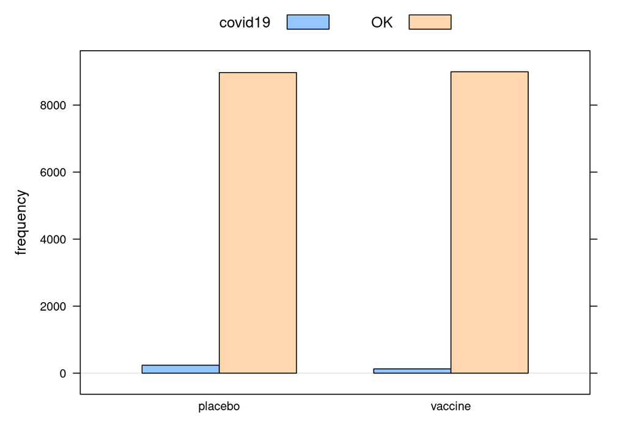

```r
females=filter(FinalData,FinalData$sex=="F")
barchartGC(~treatment + infected,data=females)
```

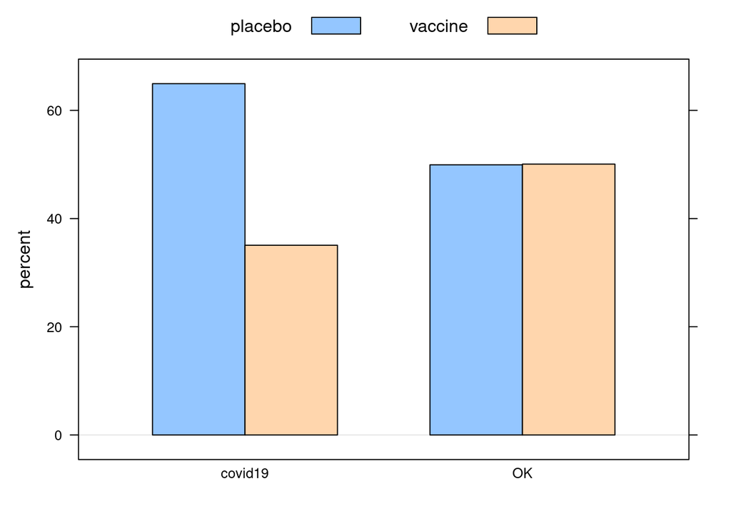

```r
barchartGC(~infected + treatment,data=females, type="percent")
```

### 1.2.4 Numerical Results

```r
table1 <- xtabs(~treatment + infected,data=females)
rowPerc(table1)
```

```
##          infected
## treatment covid19     OK  Total
##   placebo    2.57  97.43 100.00
##   vaccine    1.40  98.60 100.00
```

```r
colPerc(table1)
```

```
##          infected
## treatment covid19     OK
##   placebo   64.93  49.94
##   vaccine   35.07  50.06
##   Total    100.00 100.00
```

### 1.2.5 Inferential Results

```r
chisq.test(table1)
```

```
##
##  Pearson's Chi-squared test with Yates' continuity correction
##
## data:  table1
## X-squared = 31.58, df = 1, p-value = 1.914e-08
```

```r
chisqtestGC(table1)
```

```
## Pearson's Chi-squared test with Yates' continuity correction
##
## Observed Counts:
##          infected
## treatment covid19   OK
##   placebo     237 8970
##   vaccine     128 8993
##
## Counts Expected by Null:
##          infected
## treatment covid19      OK
##   placebo  183.36 9023.64
##   vaccine  181.64 8939.36
##
## Contributions to the chi-square statistic:
##          infected
## treatment covid19    OK
##   placebo   15.69  0.32
##   vaccine   15.84  0.32
##
##
## Chi-Square Statistic = 31.5803
## Degrees of Freedom of the table = 1
## P-Value = 0
```

```r
fisher.test(table1)
```

```
##
##  Fisher's Exact Test for Count Data
##
## data:  table1
## p-value = 1.246e-08
## alternative hypothesis: true odds ratio is not equal to 1
## 95 percent confidence interval:
##  1.487765 2.324632
## sample estimates:
## odds ratio
##   1.856237
```

The chi-squared test yields a p-value of 0.00000001914, and the Fisher’s Exact Test shows a p-value of 0.00000001246, both less than 0.05. Thus, we reject the null hypothesis. The odds ratio indicates that FEMALES are 1.86 times more likely to contract Covid921 with the placebo than with the vaccine.

## 1.3 LGBTQ

$H_0$: The Covid921 vaccine is not effective in LGBTQ Community.

$H_A$: The Covid921 vaccine is effective in LGBTQ Community.

### 1.3.1 Methods

Treatment is a categorical variable  
LGBTQ is a categorical variable  
So we use is cat~cat helper file

### 1.3.2 Descriptive Results

### 1.3.3 Graphical Results

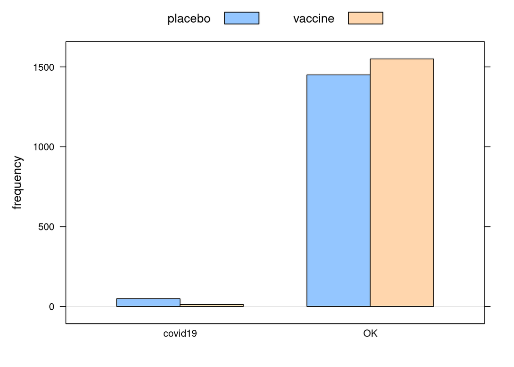

```r
LGBTQ = filter(FinalData, LGBTQ=="gay")

barchartGC(~infected + treatment,data=LGBTQ)
```

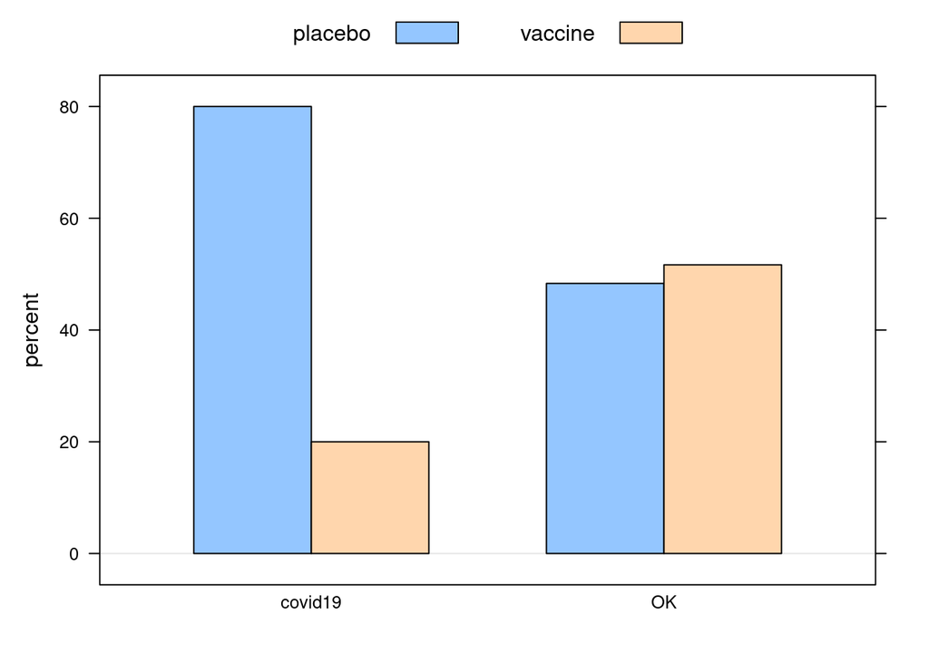

```r
barchartGC(~infected + treatment,data=LGBTQ, type="percent")
```

### 1.3.4 Numerical Results

```r
table1 <- xtabs(~treatment + infected, data=LGBTQ)
rowPerc(table1)
```

```
##          infected
## treatment covid19     OK  Total
##   placebo    3.20  96.80 100.00
##   vaccine    0.77  99.23 100.00
```

```r
colPerc(table1)
```

```
##          infected
## treatment covid19     OK
##   placebo      80  48.33
##   vaccine      20  51.67
##   Total       100 100.00
```

### 1.3.5 Inferential Results

```r
chisq.test(table1)
```

```
##
##  Pearson's Chi-squared test with Yates' continuity correction
##
## data:  table1
## X-squared = 22.355, df = 1, p-value = 2.266e-06
```

```r
chisqtestGC(table1)
```

```
## Pearson's Chi-squared test with Yates' continuity correction
##
## Observed Counts:
##          infected
## treatment covid19   OK
##   placebo      48 1450
##   vaccine      12 1550
##
## Counts Expected by Null:
##          infected
## treatment covid19      OK
##   placebo   29.37 1468.63
##   vaccine   30.63 1531.37
##
## Contributions to the chi-square statistic:
##          infected
## treatment covid19    OK
##   placebo   11.81  0.24
##   vaccine   11.33  0.23
##
##
## Chi-Square Statistic = 22.3549
## Degrees of Freedom of the table = 1
## P-Value = 0
```

```r
fisher.test(table1)
```

```
##
##  Fisher's Exact Test for Count Data
##
## data:  table1
## p-value = 7.269e-07
## alternative hypothesis: true odds ratio is not equal to 1
## 95 percent confidence interval:
##  2.225368 8.878741
## sample estimates:
## odds ratio
##    4.27359
```

The chi-squared test gives a p-value of 0.000002266, and the Fisher’s Exact Test provides a p-value of 0.0000007269, both below 0.05, so we reject the null hypothesis. This indicates a statistically significant effect of the vaccine. The odds of contracting Covid921 are significantly lower with the vaccine compared to the placebo.

## 1.4 Druggies

$H_0$: The Covid921 vaccine is not effective in Drug users

$H_A$: The Covid921 vaccine is effective in Drug users

### 1.4.1 Methods

Treatment is a categorical variable  
DRUGGIES is a categorical variable  
So we use is cat~cat helper file

### 1.4.2 Descriptive Results

### 1.4.3 Graphical Results

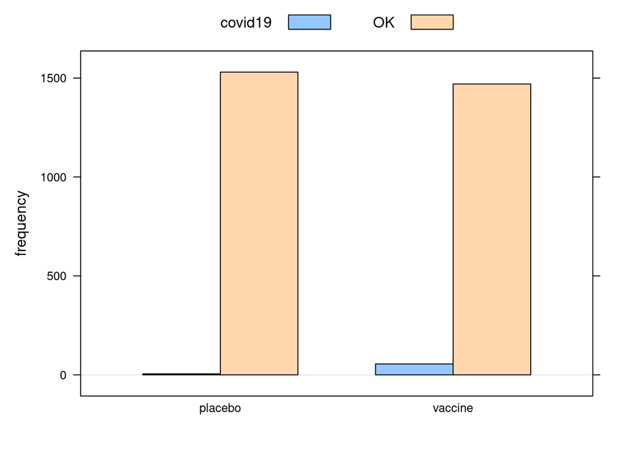

```r
DrugUser=filter(FinalData,FinalData$DrugUser=="yes")

barchartGC(~treatment + infected,data=DrugUser)
```

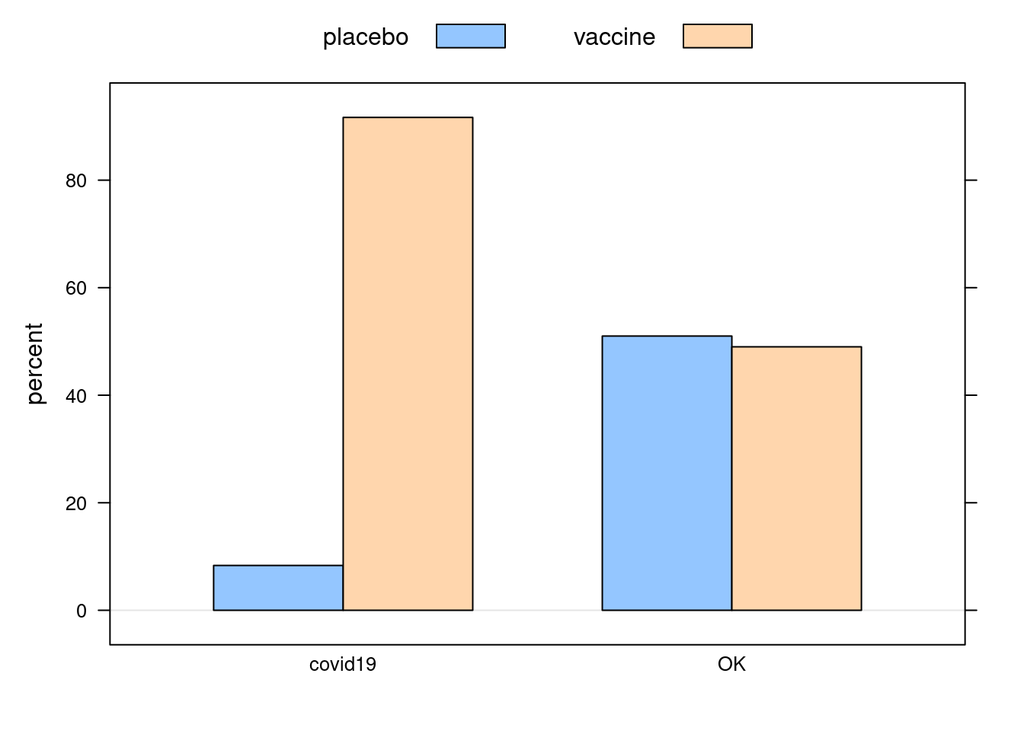

```r
barchartGC(~infected + treatment,data=DrugUser,type="percent")
```

### 1.4.4 Numerical Results

```r
table1 <- xtabs(~treatment + infected, data=DrugUser)
rowPerc(table1)
```

```
##          infected
## treatment covid19     OK  Total
##   placebo    0.33  99.67 100.00
##   vaccine    3.61  96.39 100.00
```

```r
colPerc(table1)
```

```
##          infected
## treatment covid19  OK
##   placebo    8.33  51
##   vaccine   91.67  49
##   Total    100.00 100
```

The numerical results a 3.28% difference in infection rates: 3.61% of those who received the vaccine contracted Covid921 compared to 0.33% of those who received the placebo. This suggests the vaccine may not be effective in DRUG USERS.Typically, a vaccine is expected to reduce the risk of Covid921, not increase it.

### 1.4.5 Inferential Results

```r
chisq.test(table1)
```

```
##
##  Pearson's Chi-squared test with Yates' continuity correction
##
## data:  table1
## X-squared = 41.145, df = 1, p-value = 1.414e-10
```

```r
chisqtestGC(table1)
```

```
## Pearson's Chi-squared test with Yates' continuity correction
##
## Observed Counts:
##          infected
## treatment covid19   OK
##   placebo       5 1530
##   vaccine      55 1470
##
## Counts Expected by Null:
##          infected
## treatment covid19     OK
##   placebo    30.1 1504.9
##   vaccine    29.9 1495.1
##
## Contributions to the chi-square statistic:
##          infected
## treatment covid19    OK
##   placebo   20.93  0.42
##   vaccine   21.07  0.42
##
##
## Chi-Square Statistic = 41.1448
## Degrees of Freedom of the table = 1
## P-Value = 0
```

```r
fisher.test(table1)
```

```
##
##  Fisher's Exact Test for Count Data
##
## data:  table1
## p-value = 3.261e-12
## alternative hypothesis: true odds ratio is not equal to 1
## 95 percent confidence interval:
##  0.02724646 0.21743414
## sample estimates:
## odds ratio
## 0.08740846
```

The chi-squared test yields a p-value of 0.0000000001414, and the Fisher’s Exact Test provides a p-value of 0.000000000003261. Both p-values are less than 0.05, indicating a significant difference between the vaccine and placebo groups. However, the data suggests an increased risk of infection for DRUG USERS who received the vaccine, which is an unexpected finding. Thus, we fail to reject the null hypothesis.

# 2 Individual Conclusions

## 2.4 DRUG USERS

In the case of DRUG USERS, the graphical and numerical analysis revealed a higher infection rate in the vaccine group (3.61%) compared to the placebo group (0.33%), contrary to expectations. Despite these unexpected results, both the chi-squared and Fisher’s Exact Test yielded extremely significant p-values (0.0000000001414 and 0.000000000003261, respectively). This suggests a statistically significant difference between the groups, but the observed increased infection risk with the vaccine requires further investigation to clarify these anomalous findings. With this information with the increased infection risk with the vaccine leads us to into failing to reject the null hypothesis.

# 3 Overall Results and Conclusion

The Covid921 vaccine is shown to be significantly effective in reducing the cases of Covid921 among MALES, FEMALES, and LGBTQ communities, as the null hypothesis was consistently rejected with extremely low p-values, indicating a strong protective effect compared to a placebo. However, the data for DRUG USERS suggests an unexpected increase in infection risk regardless of having a low p-value as well. This highlights the need for further investigation into possible data anomalies or specific contextual factors. Overall, the vaccine is recommended for the general population, but caution and additional analysis are advised for DRUG USERS.